# Problem Description

This Kaggle challenge provides 7613 tweets, which should form the basis for a classification task. The problem consits of distinguishing between disaster related and non desaster related tweets with respect to their respective text.

Furthermore the data contains one keyword as well as a location for each tweet. We will not use both of these features as the single keyword only gives a very narrow insight into the data and can be grosly misleading when a prediction is solely based on it. The location is not of great use either, as disasters can happen at any place and time.

This challenge and the detection of disaster tweets is highly relevant, as different usecases, like automatic monitoring of twitter tweets by disaster relief forces or governments, seem to be possible. This would highly reduce the reaction time of rescue operations in case of an emergency.

The company figure-eight created the dataset and originally shared it on their ‘Data For Everyone’ website. We have obtained the data from Kaggle via the following challenge link: https://www.kaggle.com/c/nlp-getting-started/overview.

# The Dataset

```python
import pandas as pd
import numpy as np
import matplotlib.pyplot as plt
from scipy.stats import normaltest
import tensorflow as tf
from tensorflow.keras.models import Sequential
from tensorflow.keras.layers import Dense
from tensorflow.keras.layers import LSTM
from tensorflow.keras.layers import Embedding
from tensorflow.keras.layers import TextVectorization
from tensorflow.keras.layers import Reshape
from sklearn.model_selection import train_test_split
```

```python
train = pd.read_csv('/kaggle/input/nlp-getting-started/train.csv')
train.head()
```

|  | id | keyword | location | text | target |
| --- | --- | --- | --- | --- | --- |
| 0 | 1 | NaN | NaN | Our Deeds are the Reason of this #earthquake M... | 1 |
| 1 | 4 | NaN | NaN | Forest fire near La Ronge Sask. Canada | 1 |
| 2 | 5 | NaN | NaN | All residents asked to 'shelter in place' are ... | 1 |
| 3 | 6 | NaN | NaN | 13,000 people receive #wildfires evacuation or... | 1 |
| 4 | 7 | NaN | NaN | Just got sent this photo from Ruby #Alaska as ... | 1 |

```python
print(len(train))
```

```
7613
```

The taining set at hand consits of 7613 tweets. Furthermore, the csv has five columns, which are id, keyword, location, text and target. Because of the reasons, outlined in the Problem Description section, we will ignore the columns "keyword" and "location" and focus on the text column, containing the tweet, instead. The "id" column has to be kept, as it functions as an identifier for the specific tweet in the final submission file for the competition.

Regarding the datatypes, we can say, that "id" and "target" are of type integer and boolean respectively, whereas "text" is of type string.

# Exploratory Data Analysis (EDA) and Data Cleaning

A short analysis shows, that only 7503 of the tweets are unique. So, in a first data cleaning step, we will later remove the duplicate tweets from the set.

```python
print(len(train['text'].unique()))
print(max(train['text'].apply(lambda x: len(x))))
print(min(train['text'].apply(lambda x: len(x))))
print(np.argmin(train['text'].apply(lambda x: len(x))))
train.iloc[1860,:]
```

```
7503
157
7
1882
```

```
id                                                 2673
keyword                                           crush
location                                            NaN
text        My Lil brother has a crush on mariah ??????
target                                                0
Name: 1860, dtype: object
```

A histogram of the distribution of tweet lengths looks as follows:

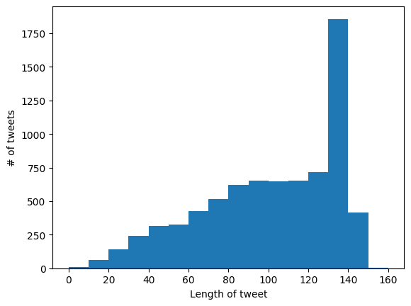

```python
plt.hist(train['text'].apply(lambda x: len(x)),range=(0,160),bins=16)
plt.xlabel('Length of tweet')
plt.ylabel('# of tweets')
```

The final fact about the data, that we have to mention, is that it is quite balanced, as 43% of the tweets constitute disaster tweets. This means that we do not have to take special care, when using algorithms that are susceptible for unbalanced datasets.

```python
# Remove unnecessary columns and duplicate tweets

train = train.iloc[:,[0,3,4]]
train = train.drop_duplicates(subset='text', keep="last")
print(len(train))
train.head()
```

```
7503
```

|  | id | text | target |
| --- | --- | --- | --- |
| 0 | 1 | Our Deeds are the Reason of this #earthquake M... | 1 |
| 1 | 4 | Forest fire near La Ronge Sask. Canada | 1 |
| 2 | 5 | All residents asked to 'shelter in place' are ... | 1 |
| 3 | 6 | 13,000 people receive #wildfires evacuation or... | 1 |
| 4 | 7 | Just got sent this photo from Ruby #Alaska as ... | 1 |

In the following we will continue our EDA by looking at word counts in more detail. For the sake of simplicity we will use a simple split operation for the word count of our tweets. This could lead to problems in cases where punctuation is standing alone separated by trailing and leading whitespaces, but this seems to be a minor drawback of the approach. Furthermore, hyperlinks could be a problem, but we will analyize them in more detail next and will for this step accept, that they might inflate the word count by one.

```
count    7503.000000
mean       14.876849
std         5.735043
min         1.000000
25%        11.000000
50%        15.000000
75%        19.000000
max        31.000000
Name: text, dtype: float64
```

```
NormaltestResult(statistic=253.1453037945962, pvalue=1.0720023098685526e-55)
```

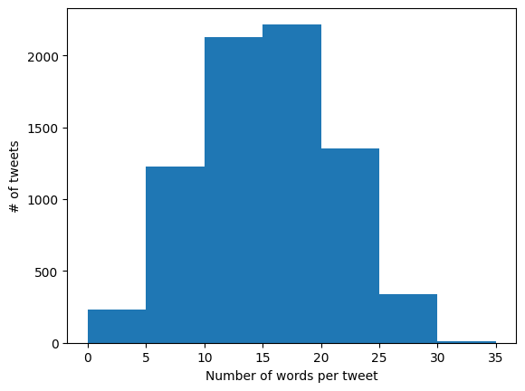

```python
print(train['text'].apply(lambda x: len(x.split())).describe())
plt.hist(train['text'].apply(lambda x: len(x.split())),range=(0,35),bins=7)
plt.xlabel('Number of words per tweet')
plt.ylabel('# of tweets')

normaltest(train['text'].apply(lambda x: len(x.split())))
```

We can see, that the mean word count is 14.87 with a minimum of 1 and a maximum of 31 in our training dataset. The histogram shows, how the word counts are distributed. One could infer, that the distribution is a normal distribution. However, this impression only arises because of the chosen bin size of 5. If we had choosen a smaller bin size like 1, we would see that the distribution is more of a bi-model type. This is also approved by the normaltest for kurtosis and skewness, which is clearly placed in the rejection region, indicating that we are not dealing with a normal distribution.

One could assume, that hyperlinks do not add much meaning to a tweet. This is why we will try to eliminate them from our dataset. First we will have a look at how many tweets contain hyperlinks.

```python
sum(train['text'].apply(lambda x: 'http' in x))/len(train)
```

```
0.5253898440623751
```

Full 53% of all tweets contain hyperlinks. This is a signifiant amount. We will try to remove them and check the operation for one specific tweet.

```python
def remove_hyperlink(x):
    if 'http' in x:
        splitted = x.split()
        splitted_new = [x for x in splitted if not x.startswith('http')]
    else:
        return(x)
    return(' '.join(splitted_new))
print(train.iloc[1308,1])
train['text'] = train['text'].apply(lambda x: remove_hyperlink(x))
print(train.iloc[1308,1])
```

```
#ika #tuning Soup #diet recipes | fat burning soup recipes: http://t.co/8r5vpAoo5z Fat Burning Soup Diet Recip http://t.co/JvcxB75DrJ
#ika #tuning Soup #diet recipes | fat burning soup recipes: Fat Burning Soup Diet Recip
```

Our method seems to work. So we will use this cleaned dataset for our following model building procedure.

```python
train = train.iloc[:,[0,1,2]]


train.head()
```

|  | id | text | target |
| --- | --- | --- | --- |
| 0 | 1 | Our Deeds are the Reason of this #earthquake M... | 1 |
| 1 | 4 | Forest fire near La Ronge Sask. Canada | 1 |
| 2 | 5 | All residents asked to 'shelter in place' are ... | 1 |
| 3 | 6 | 13,000 people receive #wildfires evacuation or... | 1 |
| 4 | 7 | Just got sent this photo from Ruby #Alaska as ... | 1 |

# Model Architecture

We will first use a text vectorization layer, that will transform each tweet into a list of integers, where the integers constitue word indices. The indices relate to the frequence of the respective word in the whole dataset. So the list 1,3 would mean, that the tweet consists of the most common word, followed by the 3th most common word. This approach is described at keras.io (see references).

Afterwards we will follow the architecture describe by Brownlee 2016.

It first uses a Word Embedding layer. This transforms the integer representations of the words into multi-dimensional vectors. These vectors will be more close to each other in cases were words have similar meaning.

This will be followed by a long and short term memory layer, like the ones described in this weeks course. In the sense of Natural Language Processing (NLP), long and short term describes the different levels of meaning in a sentence. Short term would be for example the meaning of words close to each other like a "good" followed by a "morning", whereas long term memory will more likely depict the structure of sentences like relative clauses.

The last layer is a dense output layer with a single output neuron and a sigmoid activation function. This is necessary, because we are dealing with a binary classification problem, where we are only asking for zeros and ones as outputs.

In terms of the computation algorithm we will use a simple log loss or binary cross entropy loss funtion, as this is a binary classification problem. Furthermore, we wil use the Adam optimization algorithm, as described at Brownlee 2016.

```python
test = pd.read_csv('/kaggle/input/nlp-getting-started/test.csv')
test = test.iloc[:,[0,3]]
test['text'] = test['text'].apply(lambda x: remove_hyperlink(x))



test.head()
```

|  | id | text |
| --- | --- | --- |
| 0 | 0 | Just happened a terrible car crash |
| 1 | 2 | Heard about #earthquake is different cities, s... |
| 2 | 3 | there is a forest fire at spot pond, geese are... |
| 3 | 9 | Apocalypse lighting. #Spokane #wildfires |
| 4 | 11 | Typhoon Soudelor kills 28 in China and Taiwan |

## Train Test Split

```python
training, validation = train_test_split(train,train_size=0.8,random_state=42)
```

## Text Vectorization

In a real-world setting with an ML model operating online, we would have to think about, how to handle unknown tokens or words (see https://stats.stackexchange.com/questions/163005/how-to-set-the-dictionary-for-text-analysis-using-neural-networks/163032#163032 or https://arxiv.org/abs/1707.06961 for possible approaches). This is not a problem in our setting, as we are dealing with a finite set of train and test tweets. So no unknown words will arise during the predicition phase of our task, when we adapt our Vectorizer to the whole vocabulary of the merged datasets.

```python
max_tokens = 5000
max_len = 31

vectorize_layer = tf.keras.layers.TextVectorization(
 max_tokens=max_tokens,
 standardize="lower_and_strip_punctuation",
# split="whitespace",
 output_mode='int',
 output_sequence_length=max_len)

whole_dataset = training['text'].tolist()+validation['text'].tolist()+test['text'].tolist()

vectorize_layer.adapt(whole_dataset)
```

```python
#print(vectorize_layer.get_vocabulary())
vectorize_layer.vocabulary_size()
```

```
5000
```

```python
text_vec = vectorize_layer(training['text'].tolist())
```

```python
text_vec
```

```
<tf.Tensor: shape=(6002, 31), dtype=int64, numpy=
array([[2482,    1, 3133, ...,    0,    0,    0],
       [   1,    1,   52, ...,    0,    0,    0],
       [   1,   39,   40, ...,    0,    0,    0],
       ...,
       [   1, 1548,  324, ...,    0,    0,    0],
       [   1,  722, 1621, ...,    0,    0,    0],
       [1660, 1155,  132, ...,    0,    0,    0]])>
```

We have choosen to use a vocabulary size of 5000 which seems to be a good starting point, because a initial run without restrictions yielded a size of around 28000. So we will only use 20% of the most common words or tokens. Furthermore our vectorization layer removes all punctuation from the texts and transforms it to lower case. This should help in getting a standardized output. One could argument that tweets posted in capital letters might indicate more dramatic situations. However, this is tendentious, because capital letters are a common feature in the communcation culture shaped by mediums like Instagram, X, TikTok and others. Furthermore, our text corpuses will be split along whitespaces and the "int" option for outputs yields or preferred output, where the indices of the words indicate their frequency (see explanation above).

```python
embedding_vector_length = 32
model = Sequential()
model.add(vectorize_layer)
model.add(Embedding(input_dim=max_tokens, output_dim=embedding_vector_length, input_length=max_len))
model.add(LSTM(100))
model.add(Dense(1, activation='sigmoid'))
model.compile(loss='binary_crossentropy', optimizer='adam', metrics=['accuracy','F1Score'])#F1Score
print(model.summary())
```

```
Model: "sequential"
_________________________________________________________________
 Layer (type)                Output Shape              Param #
=================================================================
 text_vectorization_1 (Text  (None, 31)                0
 Vectorization)

 embedding (Embedding)       (None, 31, 32)            160000

 lstm (LSTM)                 (None, 100)               53200

 dense (Dense)               (None, 1)                 101

=================================================================
Total params: 213301 (833.21 KB)
Trainable params: 213301 (833.21 KB)
Non-trainable params: 0 (0.00 Byte)
_________________________________________________________________
None
```

```python
[print(i.shape, i.dtype) for i in model.inputs]
print('x')
[print(o.shape, o.dtype) for o in model.outputs]
print('x')
[print(l.name, l.input_shape, l.dtype) for l in model.layers]
```

```
(None,) <dtype: 'string'>
x
(None, 1) <dtype: 'float32'>
x
text_vectorization_1 None string
embedding (None, 31) float32
lstm (None, 31, 32) float32
dense (None, 100) float32
```

```
[None, None, None, None]
```

```python
hist = model.fit(training['text'].tolist(),training['target'].astype('float32').tolist(), epochs=5, batch_size=64, validation_data=(validation['text'].tolist(),validation['target'].astype('float32').tolist()))
```

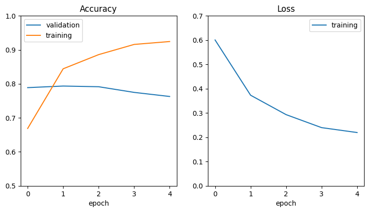

```python
epochs = list(range(len(hist.history['val_accuracy'])))
fig, axs = plt.subplots(1, 2, figsize=(9,4.5))
axs[0].plot(epochs,hist.history['val_accuracy'],label='validation')
axs[0].plot(epochs,hist.history['accuracy'],label='training')
axs[0].set_xlabel('epoch')
axs[0].set_ylim(0.50,1)
axs[0].legend()
axs[0].set_title('Accuracy')
axs[1].plot(epochs,hist.history['loss'],label='training')
axs[1].set_xlabel('epoch')
axs[1].set_ylim(0.00,0.7)
axs[1].legend()
axs[1].set_title('Loss')
```

```python
predictions = model.predict(test['text'].tolist())
preds = []
for pred in predictions:
    if pred > 0.5:
        preds.append(1)
    else:
        preds.append(0)
```

```python
result = np.column_stack((np.array(test['id']),np.array(preds)))
result
result = np.insert(result.astype(str), 0, [['id','target']], axis=0)
result = pd.DataFrame(result)
result.to_csv("/kaggle/working/out.csv",header=False, index=False)
```

We can observe, that our first model achieves a quite good performance of 80% accuracy after the second epoch. Afterwards the model quickly starts to overfit, which can be observed by the decreasing validation accurarcy and the still increasing training accuracy. The loss shows, that we are converging quite good, with a strong decrease in loss during the first epochs. After five epochs we already have centered in the local minimum, as the curve starts to show a asymptotic behaviour. The F1-score that builds the basis for the evaluation of this competition peaks at around 60%. This is not fantastic, but a point to start. In the following section, we will start to build a function around our model definition code, so that we can efficiently test and compare different optimization and model parameters.

# Optimization and Model Hyperparameter Tuning

## Function Definition

```python
def run_training_and_evaluation(max_tok,max_length,emb_vec_len,num_lstm_neurons,bat_siz):

    out_name = '/kaggle/working/'+'max_tok'+str(max_tok)+'max_l'+str(max_length)+'emb_siz'+str(emb_vec_len)+'lstm'+str(num_lstm_neurons)+'bat'+str(bat_siz)+'.csv'

    max_tokens = max_tok
    max_len = max_length

    vectorize_layer = tf.keras.layers.TextVectorization(
        max_tokens=max_tokens,
        standardize="lower_and_strip_punctuation",
        # split="whitespace",
        output_mode='int',
        output_sequence_length=max_len)

    whole_dataset = training['text'].tolist()+validation['text'].tolist()+test['text'].tolist()

    vectorize_layer.adapt(whole_dataset)

    embedding_vector_length = emb_vec_len
    model = Sequential()
    model.add(vectorize_layer)
    model.add(Embedding(input_dim=max_tokens, output_dim=embedding_vector_length, input_length=max_len))
    model.add(LSTM(num_lstm_neurons))
    model.add(Dense(1, activation='sigmoid'))
    model.compile(loss='binary_crossentropy', optimizer='adam', metrics=['accuracy','F1Score'])#F1Score


    hist = model.fit(training['text'].tolist(),training['target'].astype('float32').tolist(), epochs=5, batch_size=bat_siz, validation_data=(validation['text'].tolist(),validation['target'].astype('float32').tolist()))

    print(max(hist.history['val_accuracy']))
    print(max(hist.history['val_f1_score']))

    epochs = list(range(len(hist.history['val_accuracy'])))
    fig, axs = plt.subplots(1, 2, figsize=(9,4.5))
    axs[0].plot(epochs,hist.history['val_accuracy'],label='validation')
    axs[0].plot(epochs,hist.history['accuracy'],label='training')
    axs[0].set_xlabel('epoch')
    axs[0].set_ylim(0.50,1)
    axs[0].legend()
    axs[0].set_title('Accuracy')
    axs[1].plot(epochs,hist.history['loss'],label='training')
    axs[1].set_xlabel('epoch')
    axs[1].set_ylim(0.00,0.7)
    axs[1].legend()
    axs[1].set_title('Loss')

    predictions = model.predict(test['text'].tolist())
    preds = []
    for pred in predictions:
        if pred > 0.5:
            preds.append(1)
        else:
            preds.append(0)

    result = np.column_stack((np.array(test['id']),np.array(preds)))
    result
    result = np.insert(result.astype(str), 0, [['id','target']], axis=0)
    result = pd.DataFrame(result)
    result.to_csv(out_name,header=False, index=False)

    return()
```

With the help of the above function we will in the following test different setups of our model.

```
0.5682877898216248
[0.6030712]
0.6688874363899231
[0.6030712]
0.7634910345077515
[0.6030712]
0.7921385765075684
[0.6030712]
0.7934710383415222
[0.6030712]
```

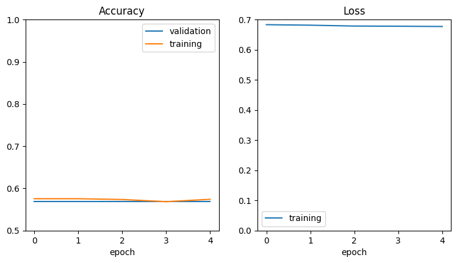

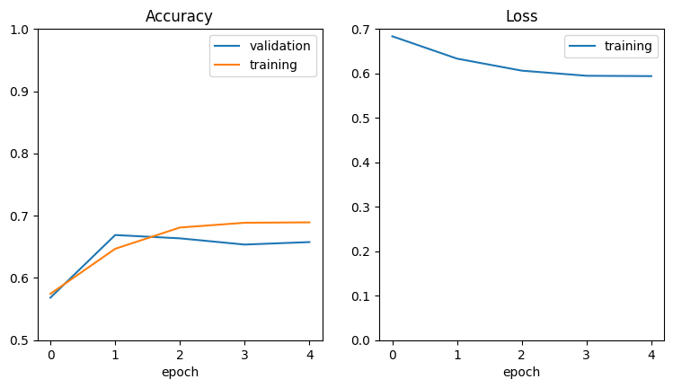

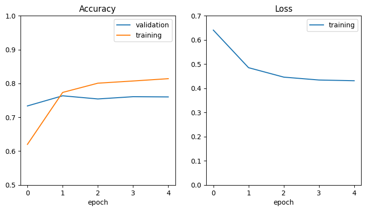

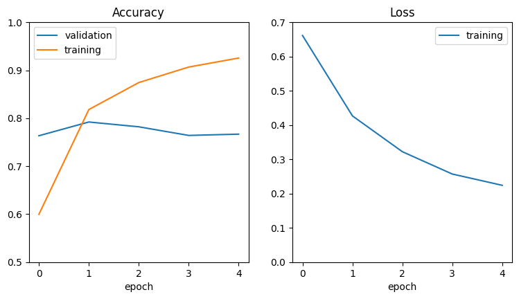

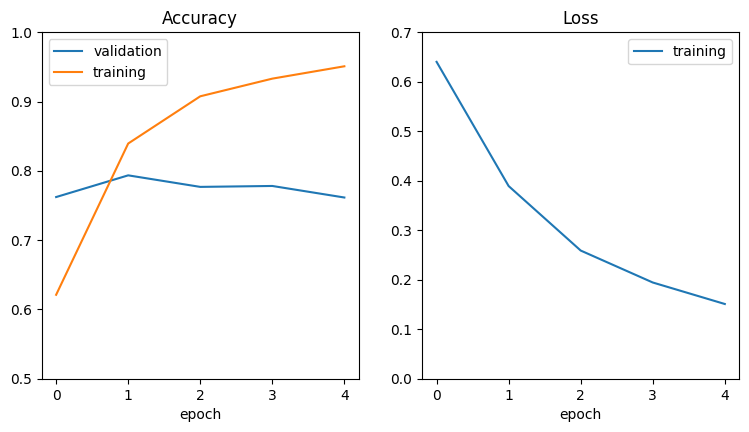

```python
a = [5,50,500,5000,10000]
b = [7,15,31]
c = [8,16,32,64]
d = [10,50,100,500,1000]
e = [64]

for max_tok in a:
    run_training_and_evaluation(max_tok,31,32,100,64)
```

The graphics show that the number of tokens in the vocabulary should not be smaller than the initial amount of 5000. 10000 tokens yield comparable results, but make the model more complex. 500 tokens lead to slighlty lower validation accuarcy and the model takes longer to converge, as the loss function has a smaller gradient. 50 and 5 tokens have been tested just for reasons of showing the behaviour of a model that is way to small. The accuracy curves of these models show clearly that both models, but especially the model with only five tokens, lack predicitve power. Furthermore, the number of trainable parameters is too small, which leads to a stagnating accuracy during the epochs.

```
0.7728181481361389
[0.6030712]
0.7868087887763977
[0.6030712]
0.7914723753929138
[0.6030712]
```

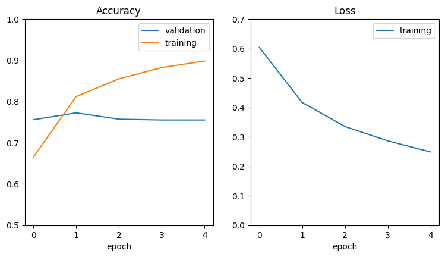

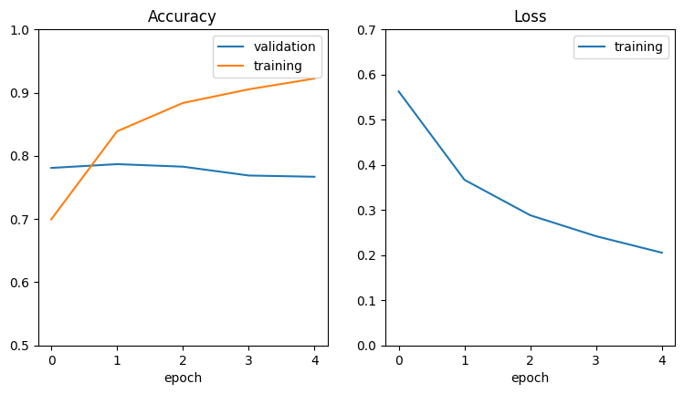

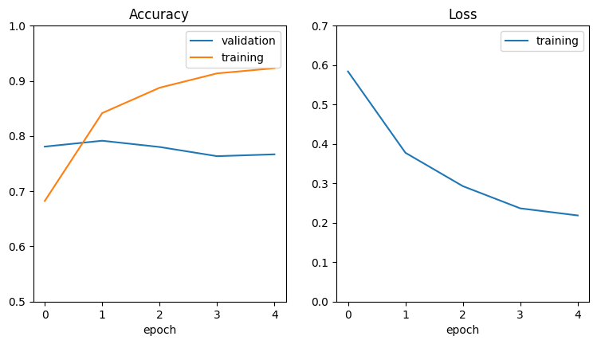

```python
for max_len in b:
    run_training_and_evaluation(5000,max_len,32,100,64)
```

```
0.7601599097251892
[0.6030712]
0.7721518874168396
[0.6030712]
0.7654896974563599
[0.6030712]
0.7674883604049683
[0.6030712]
```

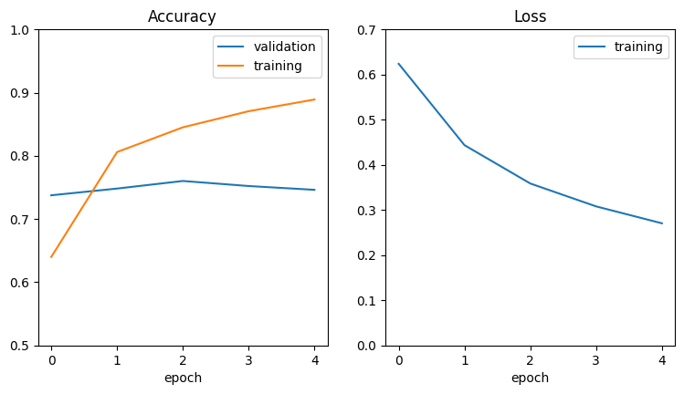

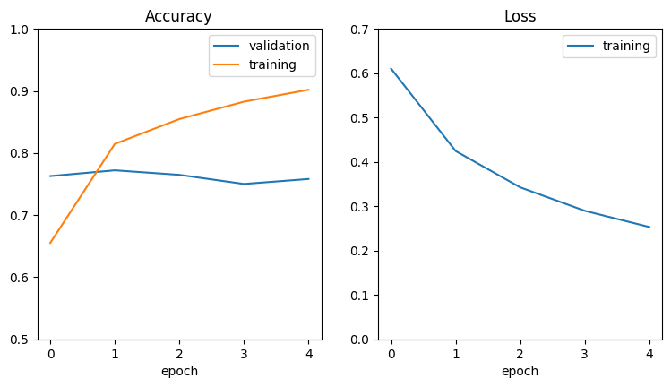

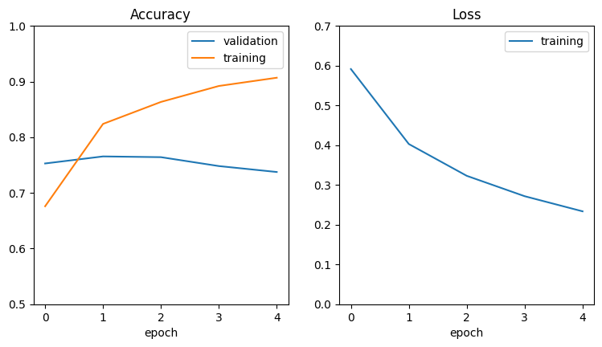

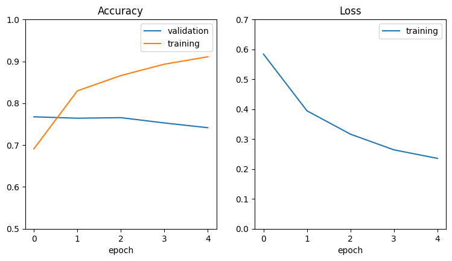

```python
for emb_vec in c:
    run_training_and_evaluation(5000,8,emb_vec,100,64)
```

Again, we can see that the size of the embedding vector is not impacting the result a lot. The vector with length 16 seems to be enough, while smaller vectors lead to slightly poorer results. A size of 32, that we have choosen first, seems to be not necessary.

```
0.7661558985710144
[0.6030712]
0.7654896974563599
[0.6030712]
0.7674883604049683
[0.6030712]
0.7694870233535767
[0.6030712]
0.7601599097251892
[0.6030712]
```

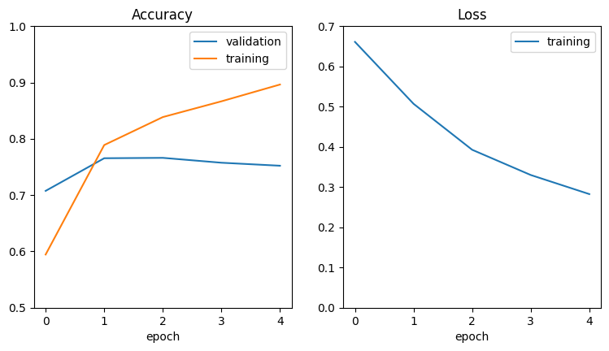

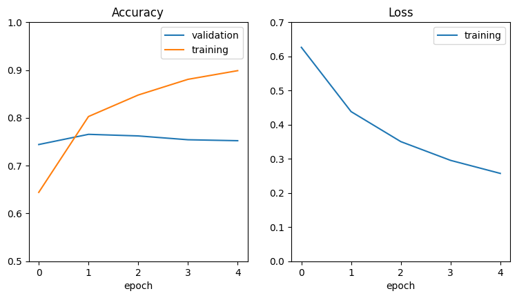

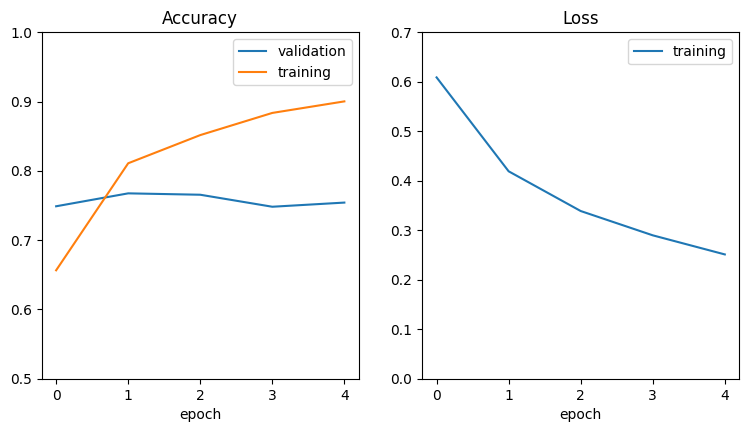

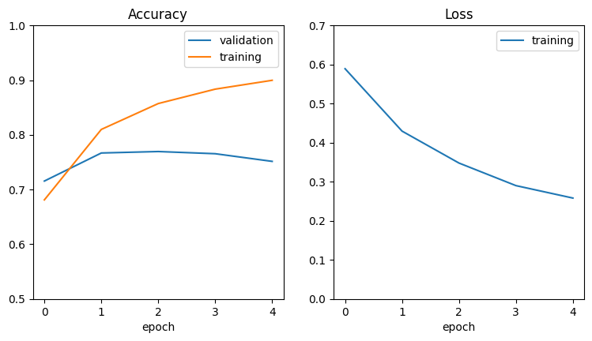

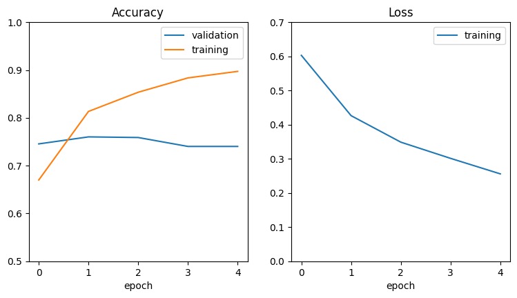

```python
for lstm in d:
    run_training_and_evaluation(5000,8,16,lstm,64)
```

Our analysis shows, that in case of our dataset a model with just fifty long-short-term-memory layers is enough to accurately predict the output. More layers do not add any additional performance to the model.

# Results and Analysis

The single optimization steps have been analized with respect to their results in the hyperparameter tuning section.

We were able to show that simpler models might be the better choice for small datasets with a limited amount of variability in the data. This is underlined by the fact, that a model of just 50 lstm layers, was able to perform as well as a model with double the amount of layers. On the other hand the analysis shows that vocabulary size is key to predictive power even for small datasets. We were not able to achieve good results with less than 5000 tokens.

Our best model in terms of the testing set on kaggle, achieved a public kaggle score of 0.77 with leaderboard position 950 on the 17th of November 2023.

# Conclusion

For me it was really interesting to observe the upper and lower limits of model sizes and their effect on predictins. A key takeaway for me is, that model size is not everything especially for small datasets. In my opinion this is an important lessons, as smaller models are simpler and also more energy efficient and should therefore be prefered. In a future work, I would definitely try to optimize the cleaning procedure of the tweets. In my opinion much potential is lying there, as steps like removing hash-tags, or removing common words, could drastically improve the input for our model and therefore its performance.

# References

Howard 2019: Addison Howard, devrishi, Phil Culliton, Yufeng Guo. (2019). Natural Language Processing with Disaster Tweets. Kaggle. https://kaggle.com/competitions/nlp-getting-started

Brownlee 2016: Jason Brownlee, Sequence Classification with LSTM Recurrent Neural Networks in Python with Keras, https://machinelearningmastery.com/sequence-classification-lstm-recurrent-neural-networks-python-keras/

tensorflow.org, Text classification with an RNN, https://www.tensorflow.org/text/tutorials/text_classification_rnn

keras.io, IMDB movie review sentiment classification dataset, https://keras.io/api/datasets/imdb/